# Expected Sale Price of Detached, Single Family Homes in Toronto and Mississauga

ER6122

October 18 2020

## I. Exploratory Data Analysis

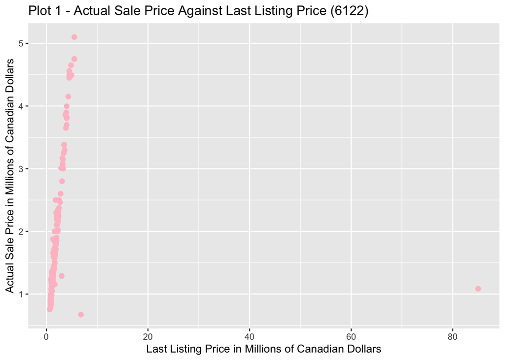

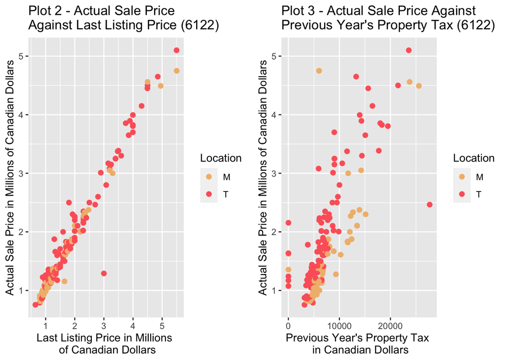

PLOT 1 The data at a first glance seems to possess a distinct linear relationship. However, there are two outlying points that clearly deviate from this pattern. It appears to have a closer linear fit than plot 2 most because these outlying points force the scale of the data to be zoomed out, giving the appearance that the fit is more precise linearity wise.

PLOT 2 This plot is similar to plot 1, but gives a more detailed picture of the trend between sale price and listing price since the outlying points are removed. It changes the scale so that it is matched to the bulk of the data. It also appears to follow a linear relationship closely, and upon magnifying the scale of the plot it seems there may be another outlying point at 3 million

PLOT 3 There appears to be some sort of trend in the data as it tends to cluster in the lower left corner, then spreads out towards the upper right corner. This could indicate a weak linear relationship, however the data becomes significantly sporadic it would require further investigation to confirm this. Another possibility may be that the data is only linear up to a certain point, possibly around 10,000 in property tax before the pattern stops making sense.

The points corresponding to Mississauga properties appear to be below those of that in Toronto. This would indicate that there is a slightly different relation between the taxes in those areas and the actual sale price. This could be because of the evident difference in demand for those areas affecting property tax values, or possibly because of different property tax policies in those respective municipal areas.

## II. Methods and Model

Table of Significant Values from Simple Linear Regressions of Listing Price Against Actual Property Selling Price; First with both Mississauga and Toronto Properties, then Mississauga Properties Only, then Toronto Properties Only (6122)

```
##                           R-squared     Intercept         Slope
## Toronto & Mississauga  9.643462e-01  1.499664e-01  9.060451e-01
## Mississauga            9.854957e-01  1.463630e-01  8.851252e-01
## Toronto                9.501671e-01  1.758830e-01  9.074182e-01
##                       Error Term Variance       P-Value Slope CI Lower
## Toronto & Mississauga        3.236741e-02 7.403467e-144   8.815039e-01
## Mississauga                  1.044281e-02  7.601046e-81   8.621067e-01
## Toronto                      4.822394e-02  3.639194e-72   8.677817e-01
##                       Slope CI Upper
## Toronto & Mississauga   9.305863e-01
## Mississauga             9.081438e-01
## Toronto                 9.470547e-01
```

The R-squared values are quite similar for all three regression lines with deviations only within approximately 0.03 of each other. The R-squared value is approximately 0.95 (95%) or more for all three models. This implies that all three of the regression models are good fits of the data and that the variation of the selling price values is mostly explained by the listing prices. It appears that the highest R value is for Mississauga with an R-squared value of 0.9855, then both areas at 0.9643 is second largest, then Toronto is smallest at 0.9502. This suggests that there is a slightly stronger relationship between listing and selling price in Mississauga compared to that of Toronto, but with such a slight difference this could just be due to the natural random variation in data.

One possible reason that they are so similar is because if there is a definitive reason that explains the relationship between listing price and selling price, it may not be significantly dependent on the general area of the properties; at least for two similar neighborhoods. In other words, if one were to do this same experiment in other areas they might still end up with high R-squared values because the location may be mostly independent of the trend. It may most likely be something to do with the process of price adjustment between the seller and the buyer to reach a sort of market equilibrium, which has shown to be a consistent phenomena in economic markets.

A pooled two-sample t-test should not be used to determine if there is a statistically significant difference between the slopes of the simple linear models. This is because to perform this test, it is necessary for the Mississauga and Toronto samples to be normally distributed which we did not check yet.

## III. Discussions and Limitations

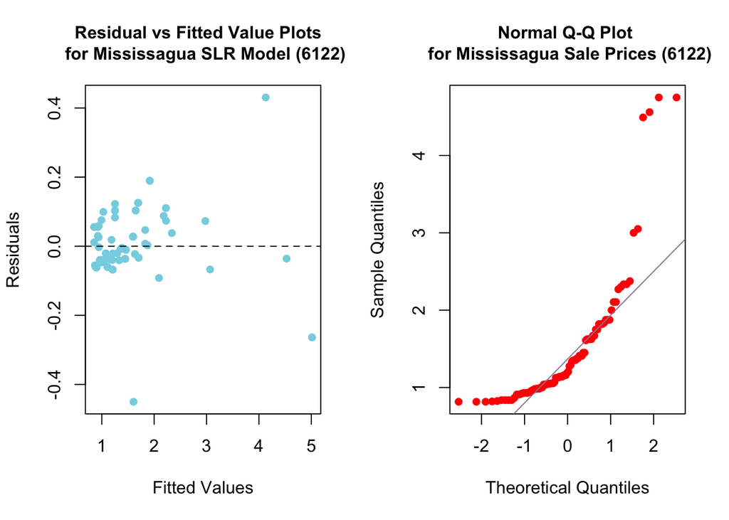

Two other potential numeric predictors could be the age of the property and distance to the nearest public transit. People tend to want to buy newer properties unless there is historic value tied to the greater age, and people tend to want to live closer to public transit. People tend to consider these things in the valuation of properties which would in turn affect sale price. These factors could be worth investigating in a multiple linear regression for sale price.